# สมาชิกในกลุ่ม

1.นายธีรเชษฐ์ เอื้ออารักษ์พงศ์ 6310401602  
2.นายกิตติภพ แซ่ตั้ง 6310402714  
3.นายทองไท มหาสุวรรณ 6310405055

ใช้ชุดข้อมูลชื่อ **Bank Marketing Dataset**  
สืบค้นได้จากลิงค์ https://archive.ics.uci.edu/dataset/222/bank+marketing

# import package ที่ใช้

```python
import pandas as pd
import numpy as np
import matplotlib.pyplot as plt
import seaborn as sns
from scipy.stats import chi2_contingency
from scipy import stats
```

# จัดเตรียมข้อมูล

**นำข้อมูลเข้า**

```python
df =  pd.read_csv('bank-full.csv')
```

ข้อมูลชุดนี้เป็นข้อมูลเกี่ยวกับแคมเปญทางการตลาดของสถาบันการเงินในประเทศโปรตุเกส ซึ่งแคมเปญดังกล่าวขึ้นอยู่กับการโทรติดต่อลูกค้า และบางครั้งต้องติดต่อลูกค้ารายเดิมมากกว่า 1 ครั้ง เพื่อให้ลูกค้าเปิดบัญชีเงินฝากประจำ

```python
df.head()
```

|  | age | job | marital | education | default | balance | housing | loan | contact | day | month | duration | campaign | pdays | previous | poutcome | y |
| --- | --- | --- | --- | --- | --- | --- | --- | --- | --- | --- | --- | --- | --- | --- | --- | --- | --- |
| 0 | 58 | management | married | tertiary | no | 2143 | yes | no | unknown | 5 | may | 261 | 1 | -1 | 0 | unknown | no |
| 1 | 44 | technician | single | secondary | no | 29 | yes | no | unknown | 5 | may | 151 | 1 | -1 | 0 | unknown | no |
| 2 | 33 | entrepreneur | married | secondary | no | 2 | yes | yes | unknown | 5 | may | 76 | 1 | -1 | 0 | unknown | no |
| 3 | 47 | blue-collar | married | unknown | no | 1506 | yes | no | unknown | 5 | may | 92 | 1 | -1 | 0 | unknown | no |
| 4 | 33 | unknown | single | unknown | no | 1 | no | no | unknown | 5 | may | 198 | 1 | -1 | 0 | unknown | no |

**ตรวจหาค่า null ในแต่ละตัวแปร**

```python
df.isnull().sum()
```

```
age          0
job          0
marital      0
education    0
default      0
balance      0
housing      0
loan         0
contact      0
day          0
month        0
duration     0
campaign     0
pdays        0
previous     0
poutcome     0
y            0
dtype: int64
```

**คัดแค่ตัวแปรที่สนใจมาทำการสำรวจข้อมูล**

```python
del df['pdays']
del df['day']
del df['poutcome']
del df['education']
del df['loan']
del df['contact']
del df['month']
```

```python
df.head()
```

|  | age | job | marital | default | balance | housing | duration | campaign | previous | y |
| --- | --- | --- | --- | --- | --- | --- | --- | --- | --- | --- |
| 0 | 58 | management | married | no | 2143 | yes | 261 | 1 | 0 | no |
| 1 | 44 | technician | single | no | 29 | yes | 151 | 1 | 0 | no |
| 2 | 33 | entrepreneur | married | no | 2 | yes | 76 | 1 | 0 | no |
| 3 | 47 | blue-collar | married | no | 1506 | yes | 92 | 1 | 0 | no |
| 4 | 33 | unknown | single | no | 1 | no | 198 | 1 | 0 | no |

# สำรวจข้อมูลแต่ละตัวแปร

## ตัวแปร subscribed

subscribed คือตัวแปรที่บอกถึงสถานะการสมัครบัญชีเงินฝากประจำ

โดยในชุดข้อมูลนี้ได้กำหนดชื่อตัวแปรนี้เป็นตัวแปร y เนื่องจากชุดข้อมูลนี้มีจุดประสงค์ที่จะให้ทำนายค่าของตัวแปรนี้

**สามารถสร้าง Pie Chart เพื่อดูความถี่ของตัวแปรสถานะการสมัครบัญชีเงินฝากประจำได้ดังนี้**

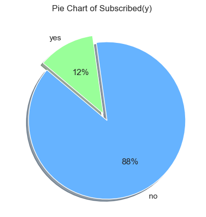

```python
gyr = ['#bae1ff','#ffb3ba','#baffc9','#ffffba','#ffdfba']
sns.set_theme(style='whitegrid',palette=gyr)
plt.figure(figsize=(5, 5))
plt.pie(df['y'].value_counts(), labels=df['y'].value_counts().index, autopct='%.0f%%', colors=['#66b3ff', '#99ff99'], explode=(0.1, 0), shadow=True, startangle=140)
plt.title('Pie Chart of Subscribed(y) ')
plt.show()
```

## ตัวแปร job

job คือ ตัวแปรที่บอกถึงประเภทงานของลูกค้าธนาคาร

**โดยมีค่าสถิติเบื้องต้นดังนี้**

```python
df['job'].describe()
```

```
count           45211
unique             12
top       blue-collar
freq             9732
Name: job, dtype: object
```

**สามารถนำมาสร้าง Bar Plot เพื่อดูความถี่ของแต่ละประเภทงานได้ดังนี้**

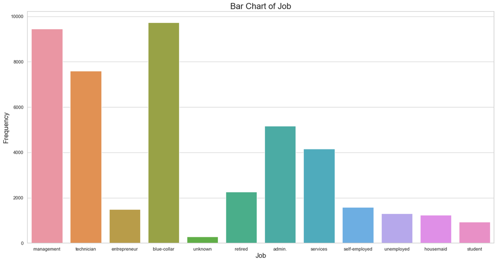

```python
plt.figure(figsize=(20, 10))
sns.countplot(x='job', data=df)
plt.title('Bar Chart of Job', fontsize=20)
plt.xlabel('Job', fontsize=16);
plt.ylabel('Frequency', fontsize=16);
plt.show()
```

พบว่ามีลูกค้าที่ไม่ทราบประเภทงานอยู่แต่เป็นสัดส่วนที่น้อย จึงทำการตัดข้อมูลที่ไม่ทราบประเภทงานของลูกค้าออก

**ตัดข้อมูลที่ไม่ทราบประเภทงานของลูกค้าออก**

```python
print(df.shape)
df = df[df['job'] != 'unknown']
print(df.shape)
```

```
(45211, 10)
(44923, 10)
```

**ลองสำรวจความถี่ของตัวแปรประเภทงานโดยแบ่งสถานะการสมัครบัญชีเงินฝากประจำ**

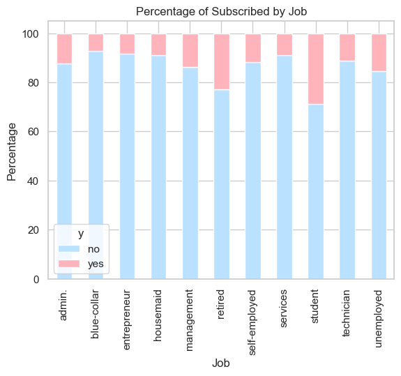

```python
table = pd.crosstab(df['job'], df['y'])
table_percentage = table.div(table.sum(axis=1), axis=0) * 100
ax = table_percentage.plot(kind='bar', stacked=True)
plt.ylabel('Percentage')
plt.xlabel('Job')
plt.title('Percentage of Subscribed by Job')
```

พบว่าลูกค้าที่เป็นนักเรียน/นักศึกษา และผู้ที่เกษียณแล้วมีสัดส่วนการสมัครบัญชีเงินฝากประจำมากที่สุด

โดยเหตุผลที่ 2 อาชีพนี้มีโอกาสเปิดบัญชีเงินฝากประจำมากนิสิตคิดว่าเป็นเพราะ ผู้ที่เกษียณอายุมักจะไม่ใช้เงินสดเป็นจำนวนมาก จึงมีแนวโน้มที่จะนำเงินไปทำให้งอกเงยโดยให้สถาบันการเงินกู้ยืม ส่วนนักเรียน/นักศึกษา คิดว่าเป็นพราะว่ามีลูกค้ากลุ่มนี้มีค่าใช้จ่ายที่ไม่สูงและมีเวลาฝากค่อนข้างมาก

## ตัวแปร marital

marital คือ ตัวแปรที่บอกถึงสถานภาพสมรสของลูกค้าธนาคาร

**โดยมีค่าสถิติเบื้องต้นดังนี้**

```python
df['marital'].describe()
```

```
count       44923
unique          3
top       married
freq        27011
Name: marital, dtype: object
```

**สามารถนำมาสร้าง Bar Plot และ Pie Chart เพื่อดูความถี่ของแต่ละสถานภาพสมรสได้ดังนี้**

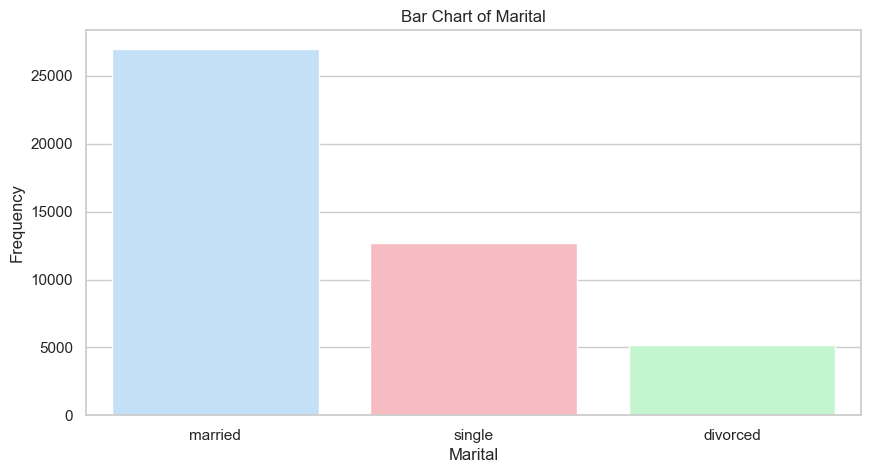

```python
plt.figure(figsize=(10,5))
sns.countplot(x='marital', data=df)
plt.title('Bar Chart of Marital')
plt.ylabel('Frequency')
plt.xlabel('Marital')
```

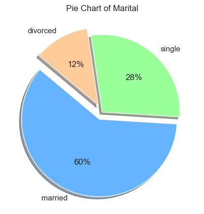

```python
plt.figure(figsize=(5, 5))
plt.pie(df['marital'].value_counts(), labels=df['marital'].value_counts().index, autopct='%.0f%%', colors=['#66b3ff', '#99ff99','#ffcc99'], explode=(0.1, 0,0.1), shadow=True, startangle=140)
plt.title('Pie Chart of Marital')
plt.show()
```

## ตัวแปร housing

housing คือตัวแปรที่บอกถึงสถานะการกู้ซื้อบ้าน

**สามารถสร้าง Bar Plot และ Pie Chart เพื่อดูความถี่ของตัวแปรสถานะการกู้ซื้อบ้านได้ดังนี้**

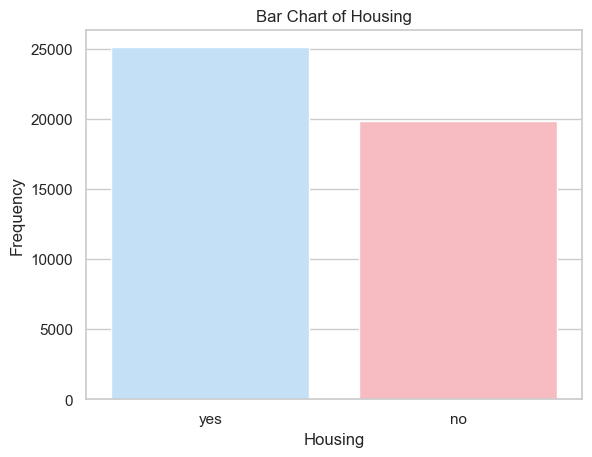

```python
sns.countplot(x='housing', data=df)
plt.title('Bar Chart of Housing')
plt.ylabel('Frequency')
plt.xlabel('Housing')
```

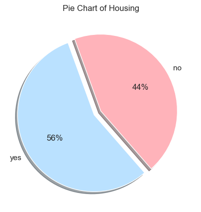

```python
plt.figure(figsize=(5, 5))
plt.pie(df['housing'].value_counts(), labels=df['housing'].value_counts().index, autopct='%.0f%%', explode=(0.1, 0), shadow=True, startangle=110)
plt.title('Pie Chart of Housing')
plt.show()
```

**ลองสำรวจอัตราส่วนของการกู้ซื้อบ้านในแต่ละอาชีพ**

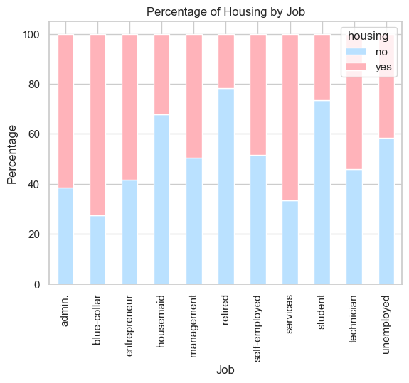

```python
table = pd.crosstab(df['job'], df['housing'])
table_percentage = table.div(table.sum(axis=1), axis=0) * 100
ax = table_percentage.plot(kind='bar', stacked=True)
plt.ylabel('Percentage')
plt.xlabel('Job')
plt.title('Percentage of Housing by Job')
```

พบว่าอาชีพที่มีอัตราส่วนการซื้อบ้านค่อนข้างมากได้แก่อาชีพ blue-collar(คนใช้แรงงาน) admin(แอดมิน) และ services(ผู้ให้บริการ)

## ตัวแปร default

default คือตัวแปรที่บอกถึงสถานะการผิดชำระหนี้

**สามารถสร้าง Pie Chart เพื่อดูความถี่ของตัวแปรสถานะการผิดชำระหนี้ได้ดังนี้**

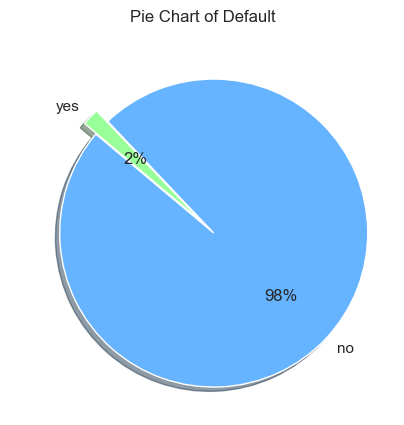

```python
plt.figure(figsize=(5, 5))
plt.pie(df['default'].value_counts(), labels=df['default'].value_counts().index, autopct='%.0f%%', colors=['#66b3ff', '#99ff99'], explode=(0.1, 0), shadow=True, startangle=140)
plt.title('Pie Chart of Default')
plt.show()
```

## ตัวแปร age

age คือ ตัวแปรที่บอกถึงอายุของผู้เปิดบัญชีแต่ละคน

**หาค่าสถิติพื้นฐานของตัวแปรอายุ**

```python
df['age'].describe()
```

```
count    44923.000000
mean        40.893529
std         10.604399
min         18.000000
25%         33.000000
50%         39.000000
75%         48.000000
max         95.000000
Name: age, dtype: float64
```

```python
df['age'].median()
```

```
39.0
```

```python
df['age'].mode()[0]
```

```
32
```

**พล็อตกราฟ Boxplot เพื่อดูหาค่าผิดปกติและดูการแจกแจงของตัวแปรอายุ**

```
[]
```

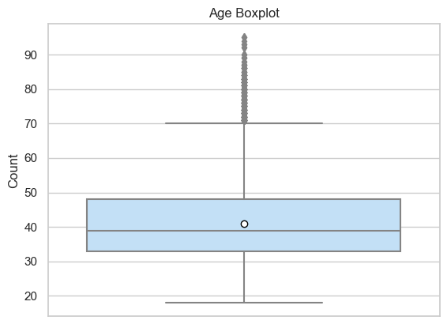

```python
sns.boxplot(data=df,y='age',showmeans = True,meanprops={"marker":"o",
                       "markerfacecolor":"white",
                       "markeredgecolor":"black",
                      "markersize":"6"})
plt.ylabel('Count')
plt.title('Age Boxplot')
plt.plot()
```

พบว่าตัวแปรอายุมี outlier บางส่วนแต่เป็นเพียงการตรวจสอบจากการค่า Whisker เท่านั้น อาจจะไม่ใช่ค่าผิดปกติจริงๆก็ได้เพราะอาจจะมีผู้เปิดบัญชีธนาคารอยู่บางส่วนที่มีอายุมากกว่า 70 เป็นแต่อาจจะเป็นส่วนน้อยเท่านั้นเอง

**ทำการพล็อตกราฟ Histogram และ KDE เพิ่มเติมเพื่อดูการแจกแจงของข้อมูลได้สะดวกขึ้น**

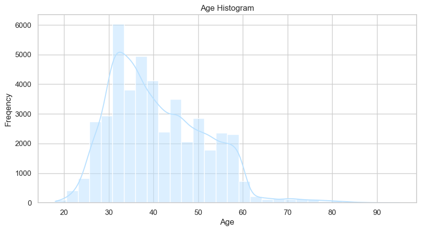

```python
plt.figure(figsize=(10, 5))
sns.histplot(df['age'],bins=30, kde=True)
plt.xlabel('Age')
plt.ylabel('Freqency')
plt.title('Age Histogram')
plt.show()
```

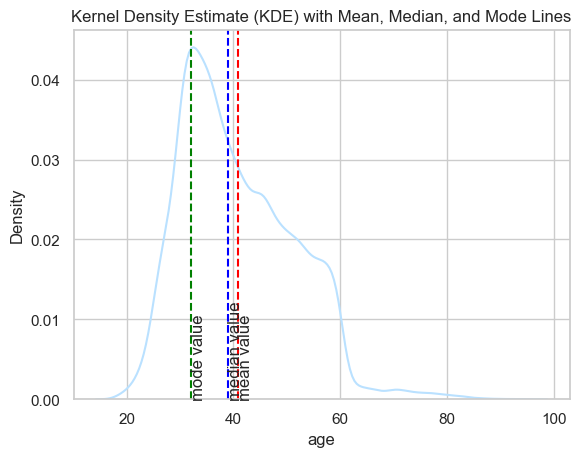

```python
ax = sns.kdeplot(df['age'])
ax.axvline(df['age'].mean(),c='r',ls='--')
ax.text(x=df['age'].mean(),y=0.0002,s="mean value", rotation=90)
ax.axvline(df['age'].median(),c='b',ls='--')
ax.text(x=df['age'].median(),y=0.0002,s="median value", rotation=90)
ax.axvline(df['age'].mode()[0],c='g',ls='--')
ax.text(x=df['age'].mode()[0],y=0.0002,s="mode value", rotation=90)
plt.title('Kernel Density Estimate (KDE) with Mean, Median, and Mode Lines')
plt.show()
```

```python
def mode(x):
    return x.mode().iloc[0]
df['age'].agg(['mean', 'median', mode])
```

```
mean      40.893529
median    39.000000
mode      32.000000
Name: age, dtype: float64
```

จากกราฟ Histogram และ KDE ทำให้พบว่าข้อมูลมีการแจกแจงแบบเบ้ขวาเล็กน้อย หรือก็คือข้อมูลของผู้ใช้บริการธนาคารแห่งนี้ คนส่วนมากเป็นคนที่อายุน้อยกว่าค่าเฉลี่ยเล็กน้อย

**สำรวจอายุโดยเฉลี่ยของแต่ละอาชีพโดยแบ่งตามสถานะการกู้ซื้อบ้าน**

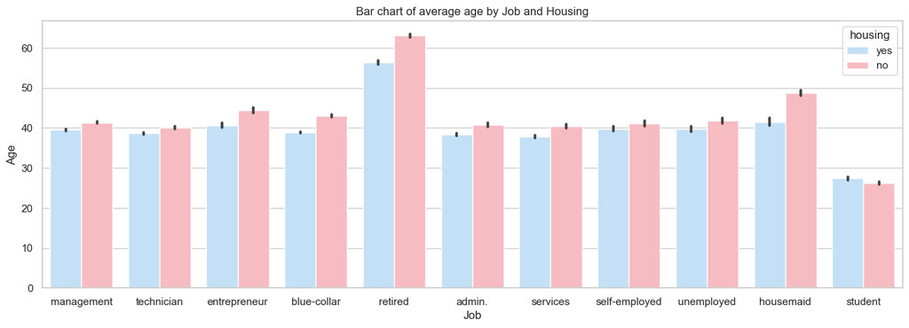

```python
plt.figure(figsize=(16,5))
sns.barplot(data=df,x='job',y='age',hue='housing')
plt.title('Bar chart of average age by Job and Housing')
plt.xlabel('Job')
plt.ylabel('Age')
```

```python
df.groupby(['job','housing'])['age'].agg(['mean', 'median', 'min', 'max', 'std', 'var'])
```

| job | housing | mean | median | min | max | std | var |
| --- | --- | --- | --- | --- | --- | --- | --- |
| admin. | no | 40.794872 | 39.0 | 20 | 75 | 10.227550 | 104.602770 |
|  | yes | 38.349151 | 37.0 | 20 | 65 | 8.653465 | 74.882456 |
| blue-collar | no | 43.015648 | 44.0 | 21 | 75 | 9.846556 | 96.954656 |
|  | yes | 38.912457 | 38.0 | 20 | 61 | 8.422444 | 70.937560 |
| entrepreneur | no | 44.404531 | 44.0 | 21 | 84 | 9.569745 | 91.580012 |
|  | yes | 40.616801 | 40.0 | 23 | 60 | 8.435264 | 71.153681 |
| housemaid | no | 48.733967 | 49.0 | 22 | 83 | 10.239371 | 104.844719 |
|  | yes | 41.510050 | 40.0 | 22 | 65 | 9.217695 | 84.965894 |
| management | no | 41.356067 | 39.0 | 21 | 81 | 9.971753 | 99.435860 |
|  | yes | 39.523301 | 37.0 | 22 | 78 | 8.644859 | 74.733581 |
| retired | no | 63.072758 | 60.0 | 24 | 95 | 9.909854 | 98.205200 |
|  | yes | 56.405295 | 58.0 | 33 | 75 | 5.466847 | 29.886421 |
| self-employed | no | 41.122850 | 40.0 | 22 | 76 | 10.151359 | 103.050080 |
|  | yes | 39.805229 | 38.0 | 24 | 62 | 9.056829 | 82.026151 |
| services | no | 40.440922 | 39.0 | 21 | 69 | 9.822218 | 96.475959 |
|  | yes | 37.886840 | 37.0 | 20 | 60 | 8.497454 | 72.206720 |
| student | no | 26.249637 | 26.0 | 18 | 48 | 5.024513 | 25.245730 |
|  | yes | 27.353414 | 27.0 | 20 | 41 | 4.202965 | 17.664918 |
| technician | no | 40.126077 | 38.0 | 21 | 71 | 9.285408 | 86.218803 |
|  | yes | 38.627947 | 37.0 | 21 | 64 | 8.578208 | 73.585655 |
| unemployed | no | 41.776316 | 41.0 | 21 | 66 | 10.608867 | 112.548055 |
|  | yes | 39.821363 | 39.0 | 21 | 60 | 8.353764 | 69.785373 |

ทุกอาชีพที่กู้ซื้อบ้านจะมีอายุเฉลี่ยน้อยกว่าคนที่ไม่ได้กู้ซื้อบ้าน ยกเว้นอาชีพนักเรียนและนักศึกษา

**สำรวจอายุโดยเฉลี่ยของแต่ละสถานภาพสมรสโดยแบ่งตามสถานะเปิดการเปิดบัญชีเงินฝากประจำ**

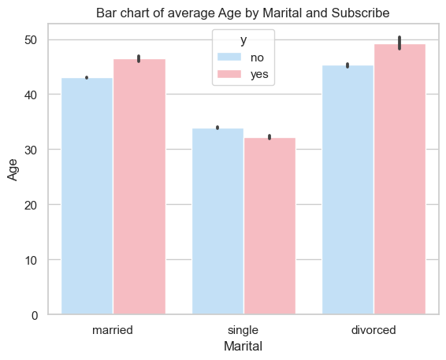

```python
sns.barplot(data=df, x='marital',y='age',hue='y')
plt.title('Bar chart of average Age by Marital and Subscribe')
plt.xlabel('Marital')
plt.ylabel('Age')
```

```python
df.groupby(['marital','y'])['age'].agg(['mean', 'median', 'min', 'max', 'std', 'var'])
```

| marital | y | mean | median | min | max | std | var |
| --- | --- | --- | --- | --- | --- | --- | --- |
| divorced | no | 45.291311 | 45.0 | 24 | 94 | 9.538213 | 90.977510 |
|  | yes | 49.254428 | 47.0 | 27 | 95 | 13.073847 | 170.925484 |
| married | no | 43.007579 | 42.0 | 20 | 95 | 9.824235 | 96.515596 |
|  | yes | 46.453914 | 45.0 | 20 | 93 | 13.075783 | 170.976104 |
| single | no | 33.934855 | 32.0 | 18 | 83 | 7.523263 | 56.599489 |
|  | yes | 32.207368 | 31.0 | 18 | 86 | 7.785916 | 60.620483 |

**ลองทำการแบ่งกลุ่มช่วงอายุเพื่อวิเคราะห์ข้อมูลเพิ่มเติม**

```python
def age_group(age):
    if age <= 20:
        return '0-20'
    elif age <= 30:
        return '21-30'
    elif age <= 40:
        return '31-40'
    elif age <= 50:
        return '41-50'
    elif age <= 60:
        return '51-60'
    elif age <= 70:
        return '61-70'
    elif age <= 80:
        return '71-80'
    else :
        return '>80'
```

```python
df['age_group'] = df.apply(lambda x : age_group(x.age),axis=1)
```

**สำรวจแต่ละกลุ่มอายุ โดยแบ่งตามสถานะการเปิดบัญชีเงินฝากประจำ**

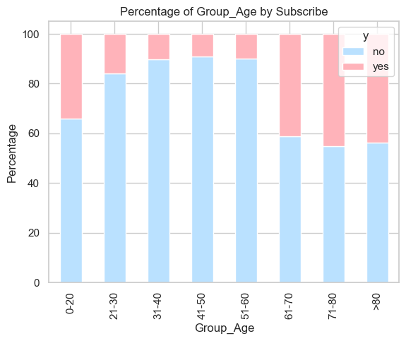

```python
table = pd.crosstab(df['age_group'], df['y'])
table_percentage = table.div(table.sum(axis=1), axis=0) * 100
ax = table_percentage.plot(kind='bar', stacked=True)
plt.ylabel('Percentage')
plt.xlabel('Group_Age')
plt.title('Percentage of Group_Age by Subscribe')
```

จากกราฟทำให้ทราบว่า ลูกค้าที่มีแนวโน้มจะเปิดบัญชีเงินฝากประจำจะอยู่ในช่วงอายุ 20 ปีหรือต่ำกว่า และช่วงอายุ 60 ปีขึ้นไป

### ตัวแปร balance

Balance คือ ตัวแปรที่บอกถึงยอดเงินคงเหลือเฉลี่ยต่อปีของผู้เปิดบัญชีแต่ละคน

**หาค่าสถิติพื้นฐานของตัวแปรยอดเงินในบัญชี**

```python
df['balance'].describe()
```

```
count     44923.000000
mean       1359.643011
std        3045.091520
min       -8019.000000
25%          72.000000
50%         447.000000
75%        1421.000000
max      102127.000000
Name: balance, dtype: float64
```

```python
df['balance'].median()
```

```
447.0
```

**พล็อตกราฟ Boxplot เพื่อดูหาค่าผิดปกติและดูการแจกแจงของตัวแปรยอดเงินในบัญชี**

```
[]
```

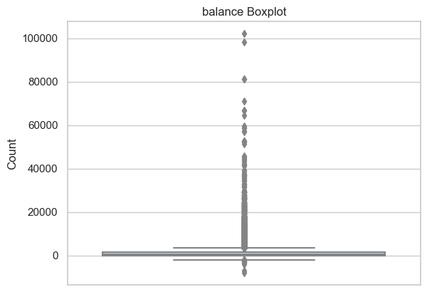

```python
sns.boxplot(data=df,y='balance')
plt.ylabel('Count')
plt.title('balance Boxplot')
plt.ylim()
plt.plot()
```

จาก Boxplot พบว่าตัวแปรยอดเงินในบัญชี มียอดเงินในบัญชีที่มากผิดปกติถ้าเทียบกับยอดเงินในบัญชีส่วนใหญค่อนข้างเยอะ

**จึงทำการพล็อคกราฟ Histogram และ KDE โดยกำหนดช่วงของข้อมูลเพื่อให้สามารถตรวจดูการแจกแจงของข้อมูลได้สะดวกขึ้น**

```
[]
```

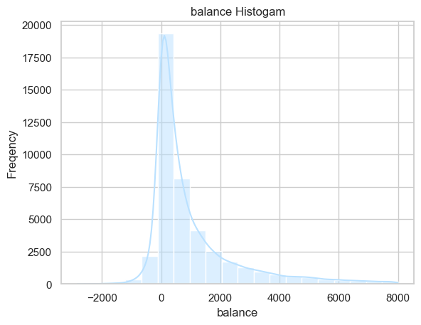

```python
sns.histplot(df[(df['balance']>=-3000)&(df['balance']<=8000)],x='balance',bins=20, kde=True)
plt.xlabel('balance')
plt.ylabel('Freqency')
plt.title('balance Histogam')
plt.plot()
```

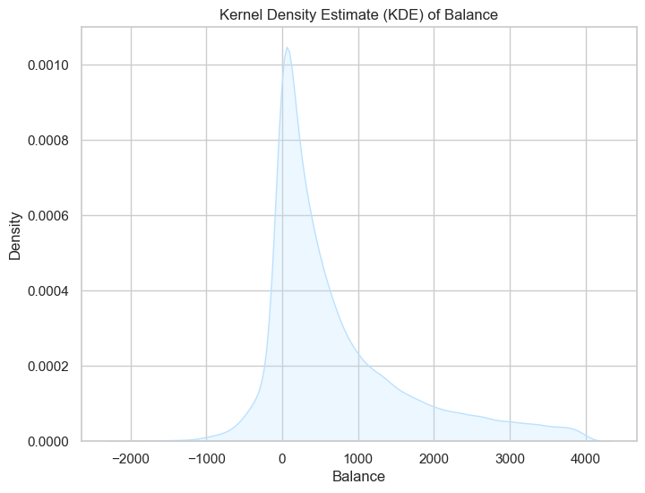

```python
plt.figure(figsize=(8, 6))
sns.kdeplot(data=df['balance'][(df['balance'] <= 4000) & (df['balance'] >= -2000)], fill=True)
plt.title('Kernel Density Estimate (KDE) of Balance')
plt.xlabel('Balance')
plt.ylabel('Density')
plt.show()
```

จากกราฟ Histogram และ KDE ทำให้พบว่าข้อมูลมีการแจกแจงแบบเบ้ขวา หรือก็คือข้อมูลของผู้ใช้บริการธนาคารแห่งนี้มีคนที่มียอดเงินในบัญชีต่ำกว่าค่าเฉลี่ยเป็นส่วนมาก

**ทำการสำรวจข้อมูลยอดเงินในบัญชีของแต่ละอาชีพ**

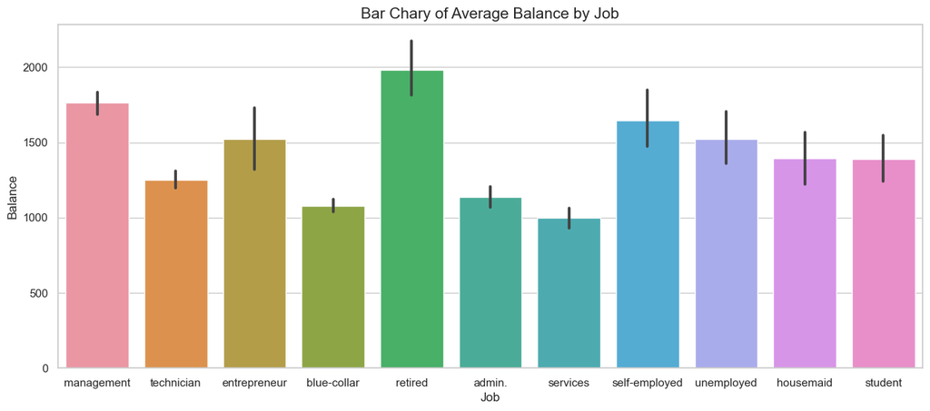

```python
fig = plt.figure(figsize =(15,6))
sns.barplot(data=df,x='job',y='balance')
plt.title('Bar Chary of Average Balance by Job',fontsize=15)
plt.ylabel('Balance')
plt.xlabel('Job')
```

```python
df[['job', 'balance']].groupby('job').agg(['mean', 'median', 'min', 'max', 'std', 'var'])
```

| job | balance mean | balance median | balance min | balance max | balance std | balance var |
| --- | --- | --- | --- | --- | --- | --- |
| admin. | 1135.838909 | 396.0 | -1601 | 64343 | 2641.962686 | 6.979967e+06 |
| blue-collar | 1078.826654 | 388.0 | -8019 | 66653 | 2240.523208 | 5.019944e+06 |
| entrepreneur | 1521.470074 | 352.0 | -2082 | 59649 | 4153.442626 | 1.725109e+07 |
| housemaid | 1392.395161 | 406.0 | -1941 | 45141 | 2984.692098 | 8.908387e+06 |
| management | 1763.616832 | 572.0 | -6847 | 102127 | 3822.965605 | 1.461507e+07 |
| retired | 1984.215106 | 787.0 | -1598 | 81204 | 4397.044177 | 1.933400e+07 |
| self-employed | 1647.970868 | 526.0 | -3313 | 52587 | 3684.259573 | 1.357377e+07 |
| services | 997.088108 | 339.5 | -2122 | 57435 | 2164.493505 | 4.685032e+06 |
| student | 1388.060768 | 502.0 | -679 | 24025 | 2441.703526 | 5.961916e+06 |
| technician | 1252.632092 | 421.0 | -2827 | 45248 | 2548.544019 | 6.495077e+06 |
| unemployed | 1521.745971 | 529.0 | -1270 | 44134 | 3144.666754 | 9.888929e+06 |

จากกราฟทำให้เห็นว่า ผู้ที่เกษียนแล้ว ผู้บริหาร และผู้ที่ทำธุรกิจส่วนตัว มียอดเงินคงเหลือเฉลี่ยในบัญชีมากที่สุดตามลำดับ

เนื่องจากตัวแปรยอดเงินในบัญชีมีทั้งยอดเงินที่ติดลบ ยอดเงินที่เป็น 0 และยอดเงินที่มากกว่า 0 จึงสร้างฟังก์ชันขึ้นมาใหม่เพื่อสร้างตัวแปรใหมที่จะทำการแบ่งประเภทของยอดบัญชี 3 ประเภทดังกล่าง

**ทำการสร้างตัวแปรประเภทกลุ่มใหม่โดยแบ่งกลุ่มตามยอดเงินในบัญชี**

```python
def group_balance(balance):
      if balance < 0 :
        return "Bad Account"
      elif balance <72:
        return "Low Account"
      elif balance < 1421:
        return "Normal Account"
      elif balance > 1421 :
        return "High Account"
```

```python
df['group_balance'] = df.apply(lambda x : group_balance(x.balance),axis=1)
```

**ลองตรวจสอบความถี่ของประเภทบัญชีแต่ละประเภทโดยแบ่งตามสถานะการซื้อบ้าน**

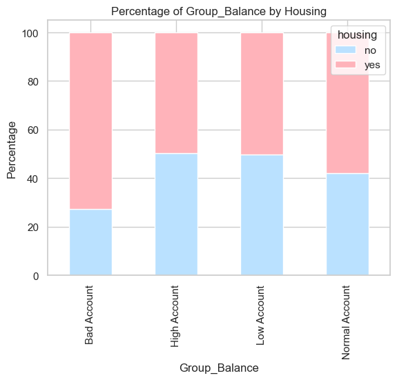

```python
table = pd.crosstab(df['group_balance'], df['housing'])
table_percentage = table.div(table.sum(axis=1), axis=0) * 100
ax = table_percentage.plot(kind='bar', stacked=True)
plt.ylabel('Percentage')
plt.xlabel('Group_Balance')
plt.title('Percentage of Group_Balance by Housing')
```

พบว่าสาเหตุที่ ลูกค้าที่มียอดเงินคงเหลือเฉลี่ยในบัญชีติดลบมีสาเหตุบางส่วนมาจากการกู้ซื้อบ้าน

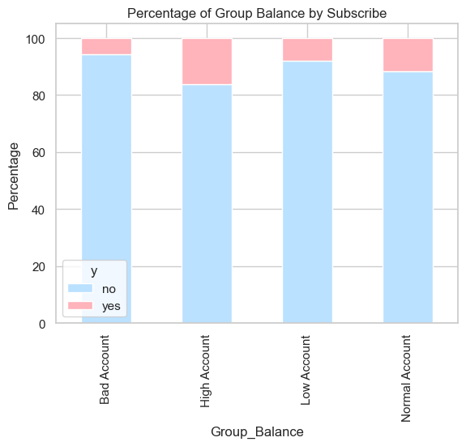

```python
table = pd.crosstab(df['group_balance'], df['y'])
table_percentage = table.div(table.sum(axis=1), axis=0) * 100
ax = table_percentage.plot(kind='bar', stacked=True)
plt.ylabel('Percentage')
plt.xlabel('Group_Balance')
plt.title('Percentage of Group Balance by Subscribe')
```

แคมเปญการตลาดครั้งต่อไปควรมุ่งเน้นไปที่บุคคลที่มียอดคงเหลือปานกลางและสูงเพื่อเพิ่มโอกาสในการเปิดบัญชีเงินฝากประจำ

## ตัวแปร duration

Duration คือ ตัวแปรที่บอกถึงระยะเวลาการโทรมาขายแคมเปญครั้งล่าสุด(หน่วยเป็นวินาที)

**หาค่าสถิติพื้นฐานของตัวแปรระยะเวลาการโทร**

```python
df['duration'].describe()
```

```
count    44923.000000
mean       258.294838
std        257.713770
min          0.000000
25%        103.000000
50%        180.000000
75%        319.000000
max       4918.000000
Name: duration, dtype: float64
```

```python
df['duration'].mode()
```

```
0    124
Name: duration, dtype: int64
```

```python
df['duration'].median()
```

```
180.0
```

**พล็อตกราฟ Boxplot เพื่อหาค่าผิดปกติและดูการแจกแจงของตัวแปรระยะเวลาการโทร**

```
[]
```

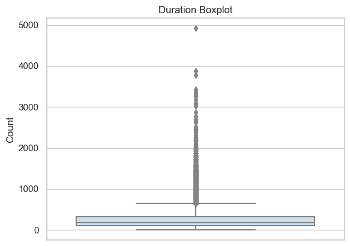

```python
sns.boxplot(data=df,y='duration')
plt.ylabel('Count')
plt.title('Duration Boxplot')
plt.ylim()
plt.plot()
```

จาก Boxplot พบว่าตัวแปรยอดระยะเวลาการโทร มีระยะเวลาการโทรที่มากผิดปกติถ้าเทียบกับระยะเวลาการโทรส่วนใหญค่อนข้างเยอะ

**ทำการพล็อคกราฟ Histogram และ KDE โดยกำหนดช่วงของข้อมูลเพื่อให้สามารถตรวจดูการแจกแจงของข้อมูลได้ง่ายๆ**

```
[]
```

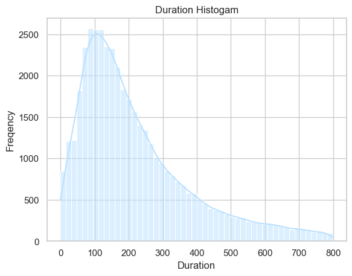

```python
sns.histplot(df[(df['duration']<800)&(df['duration']>=0)], bins=50,x='duration', kde=True)
plt.xlabel('Duration')
plt.ylabel('Freqency')
plt.title('Duration Histogam')
plt.plot()
```

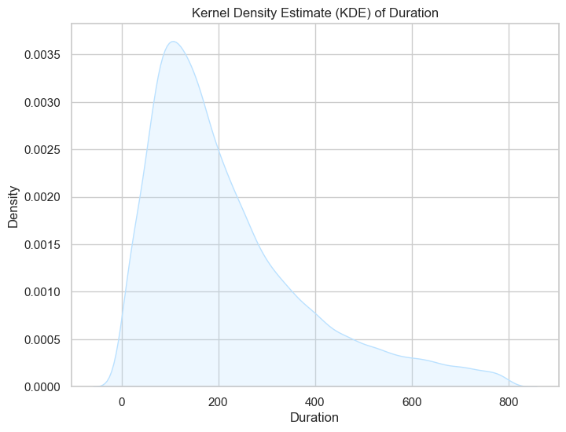

```python
plt.figure(figsize=(8, 6))
sns.kdeplot(data=df['duration'][(df['duration'] < 800) & (df['duration'] >= 0)], fill=True)
plt.title('Kernel Density Estimate (KDE) of Duration')
plt.xlabel('Duration')
plt.ylabel('Density')
plt.show()
```

จากกราฟ Histogram และ KDE ทำให้พบว่าข้อมูลมีการแจกแจงแบบเบ้ขวาเล็กน้อย

**ลองสร้าง Box plot โดยเปรียบเทียบการแจกแจงของตัวแปรระยะเวลาการโทรโดยแบ่งตามสถานะการสมัครบัญชีเงินฝากประจำ**

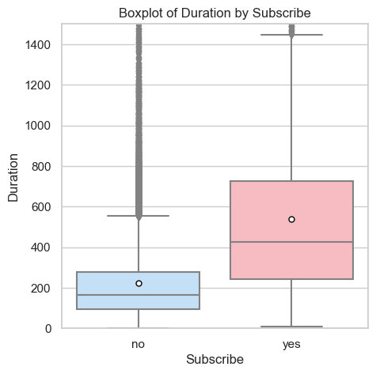

```python
fig = plt.figure(figsize =(5,5))
sns.boxplot(data = df,x ='y',y = 'duration',showmeans = True,meanprops={"marker":"o",
                       "markerfacecolor":"white",
                       "markeredgecolor":"black",
                      "markersize":"5"})
plt.ylim([0,1500])
plt.title('Boxplot of Duration by Subscribe')
plt.ylabel('Duration')
plt.xlabel('Subscribe')
```

```python
df[['duration', 'y']].groupby('y').agg(['mean', 'median', 'min', 'max', 'std', 'var'])
```

| y | duration mean | duration median | duration min | duration max | duration std | duration var |
| --- | --- | --- | --- | --- | --- | --- |
| no | 221.282117 | 164.0 | 0 | 4918 | 207.472097 | 43044.670881 |
| yes | 537.689819 | 426.0 | 8 | 3881 | 393.017588 | 154462.824592 |

พบว่าข้อมูลของลูกค้าที่สมัครบัญชีเงินฝากประจำมีค่ากลางที่สูงกว่าลูกค้าที่ไม่สมัคร และข้อมูลของผู้ที่สมัครบัญชีเงินฝากประจำก็มีการกระจายตัวที่สูงกว่าอีกด้วย

เนื่องจากข้อมูลของตัวแปรระยะเวลาการโทรมีการกระจายตัวของข้อมูลค่อนข้างมาก จึงทำการแบ่งกลุ่มของข้อมูลเพิ่มเติมเพื่อให้เข้าใจตัวแปรนี้ได้มากขึ้น

**ทำการแบ่งกลุ่มของระยะเวลาการโทร**

```python
def group_duration(duration):
    if duration < 300 :
        return "<5min"
    elif duration < 600 and duration >= 300:
        return "5min-10min"
    elif duration < 900 and duration >= 600:
        return "10min-15min"
    elif duration < 1200 and duration >= 900:
        return "15min-20min"
    else :
        return "from 20 minutes or more"
```

```python
df['group_duration'] = df.apply(lambda x : group_duration(x.duration),axis=1)
```

**ลองตรวจสอบความถี่ของระยะเวลาการโทรแต่ละกลุ่มโดยแบ่งตามสถานะการสมัครบัญชีเงินฝากประจำ**

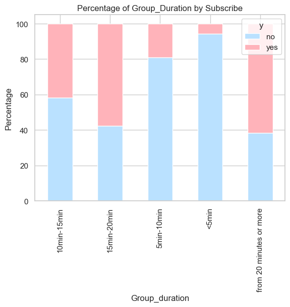

```python
table = pd.crosstab(df['group_duration'], df['y'])
table_percentage = table.div(table.sum(axis=1), axis=0) * 100
ax = table_percentage.plot(kind='bar', stacked=True)
plt.ylabel('Percentage')
plt.xlabel('Group_duration')
plt.title('Percentage of Group_Duration by Subscribe')
```

จากกราฟพบว่า ยิ่งเป็นกลุ่มที่มีระยะเวลาการทำโทรที่มากขึ้นก็จะยิ่งมีสัดส่วนของผู้ที่สมัครบัญชีเงินฝากประจำมากขึ้น ดังนั้นการทำให้ความยาวของบทสนทนาเพิ่มขึ้นอาจจะช่วยเพิ่มโอกาสในการเปิดบัญชีเงินฝากประจำของลูกค้าได้

## ตัวแปร campaign

campaign คือตัวแปรที่บอกถึงจำนวนผู้ติดต่อที่ทำระหว่างแคมเปญนี้

**หาค่าสถิติพื้นฐานของตัวแปรแคมเปญ**

```python
df['campaign'].describe()
```

```
count    44923.000000
mean         2.760345
std          3.092838
min          1.000000
25%          1.000000
50%          2.000000
75%          3.000000
max         63.000000
Name: campaign, dtype: float64
```

**ทำการพล็อคกราฟ Histogram โดยกำหนดช่วงของข้อมูลเพื่อให้สามารถตรวจดูการแจกแจงของข้อมูลได้สะดวกขึ้น**

```
[]
```

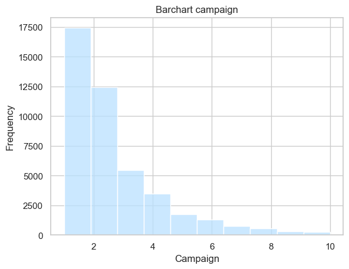

```python
sns.histplot(df[(df['campaign']<=10)],x='campaign',bins=10)
plt.xlabel('Campaign')
plt.ylabel('Frequency')
plt.title('Barchart campaign')
plt.plot()
```

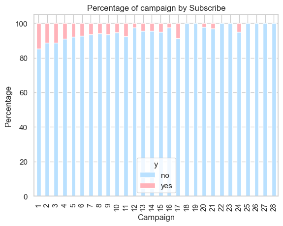

```python
table = pd.crosstab(df[(df['campaign']<=28)]['campaign'], df['y'])
table_percentage = table.div(table.sum(axis=1), axis=0) * 100
ax = table_percentage.plot(kind='bar', stacked=True)
plt.ylabel('Percentage')
plt.xlabel('Campaign')
plt.title('Percentage of campaign by Subscribe')
```

จากกราฟ Campaign success rate ทำให้พบว่ายิ่งติดต่อลูกค้ามากเท่าไร ลูกค้ายิ่งมีแนวโน้มจะปฏิเสธการสมัครบัญชีเงินฝากประจำ ดังนั้นเพื่อลดเวลาและทรัพยากรไม่ควรโทรหาลูกค้าคุณภาพเกิน 3 ครั้ง

## ตัวแปร previous

ตัวแปร previous หมายถึงจำนวนผู้ติดต่อที่ดำเนินการก่อนเริ่มแคมเปญนี้สำหรับลูกค้ารายนี้

**หาค่าสถิติพื้นฐานของตัวแปร**

```python
df['previous'].describe()
```

```
count    44923.000000
mean         0.581996
std          2.309077
min          0.000000
25%          0.000000
50%          0.000000
75%          0.000000
max        275.000000
Name: previous, dtype: float64
```

**ทำการพล็อคกราฟ Histogram โดยกำหนดช่วงของข้อมูลเพื่อให้สามารถตรวจดูการแจกแจงของข้อมูลได้สะดวกขึ้น**

```
[]
```

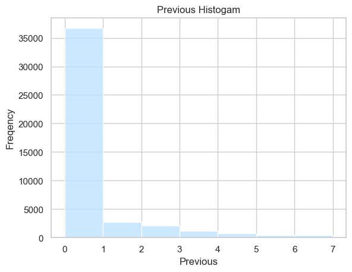

```python
sns.histplot(df[(df['previous']<=7)&(df['previous']>=0)],x = 'previous',bins=7)
plt.xlabel('Previous')
plt.ylabel('Freqency')
plt.title('Previous Histogam')
plt.plot()
```

## ทำการหาค่าความสัมพันธ์ของตัวแปร numberic แต่ละตัว

```python
df[['age','duration','balance','campaign','previous']].corr()
```

|  | age | duration | balance | campaign | previous |
| --- | --- | --- | --- | --- | --- |
| age | 1.000000 | -0.004521 | 0.097949 | 0.004330 | 0.001573 |
| duration | -0.004521 | 1.000000 | 0.021629 | -0.084356 | 0.000749 |
| balance | 0.097949 | 0.021629 | 1.000000 | -0.015042 | 0.016936 |
| campaign | 0.004330 | -0.084356 | -0.015042 | 1.000000 | -0.032428 |
| previous | 0.001573 | 0.000749 | 0.016936 | -0.032428 | 1.000000 |

**นำค่า correlation มาสร้างสร้างเป็น Heatmap เพื่อให้มองค่าได้สะดวกขึ้น**

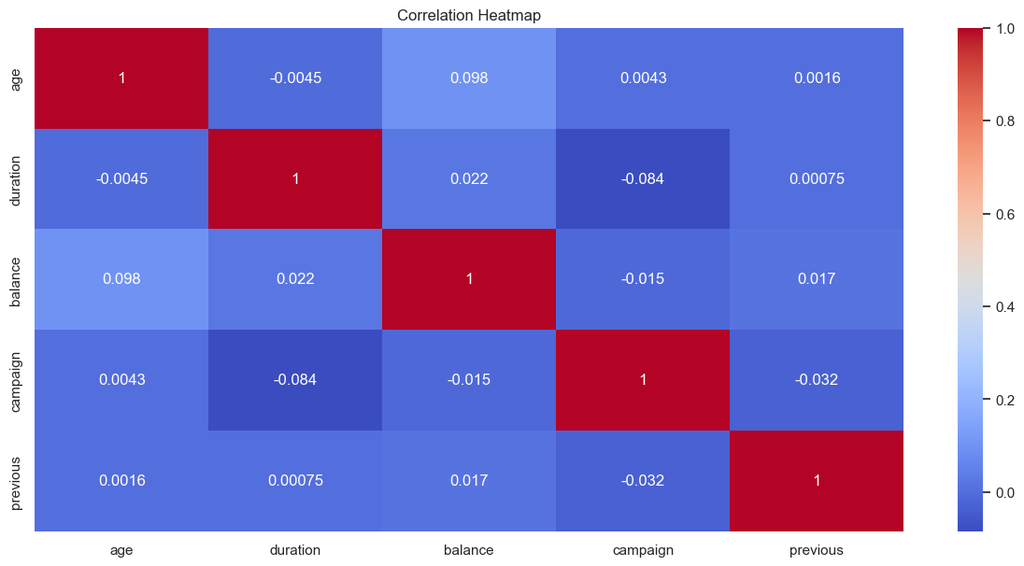

```python
fig = plt.figure(figsize=(15, 7))
sns.heatmap(df[['age','duration','balance','campaign','previous']].corr(), annot=True, cmap='coolwarm')
plt.title('Correlation Heatmap')
plt.show()
```

**ทำการสร้างกราฟ scatter plot เพื่อดูความสัมพันธ์ของแต่ละตัวแปรว่าตรงตามค่า correlation ไหม**

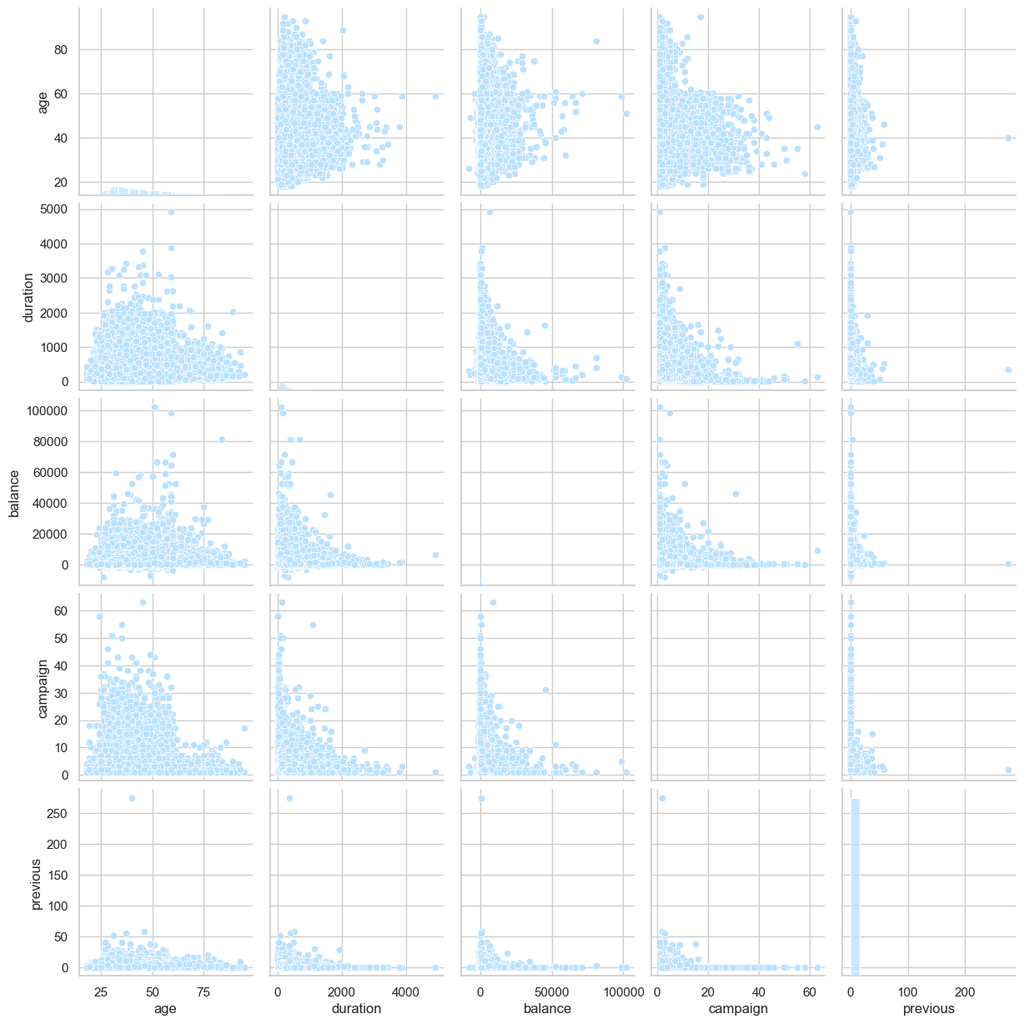

```python
sns.pairplot(data = df[['age','duration','balance','campaign','previous']])
```

### สำรวจตัวแปรบางคู่ที่น่าสนใจ

**ตัวแปร campaign และตัวแปร duration**

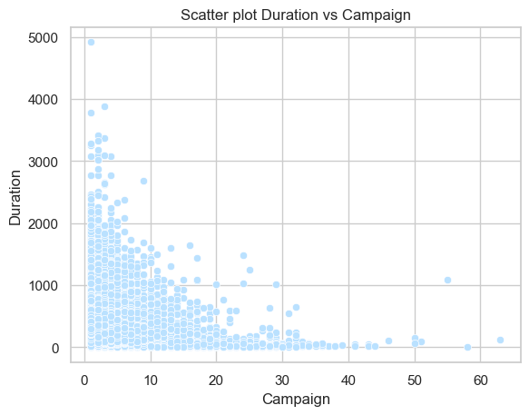

```python
sns.scatterplot(data=df,x='campaign',y='duration')
plt.title('Scatter plot Duration vs Campaign')
plt.ylabel('Duration')
plt.xlabel('Campaign')
```

พบสำหรับผู้ที่ถูกติดต่อมากจะมีระยะเวลาการโทรที่น้อยอย่างเห็นได้ชัด ส่วนผู้ที่ถูกติดต่อแรกๆจะมีระยะการโทรที่ทั้งน้อยและนานปนกันไป

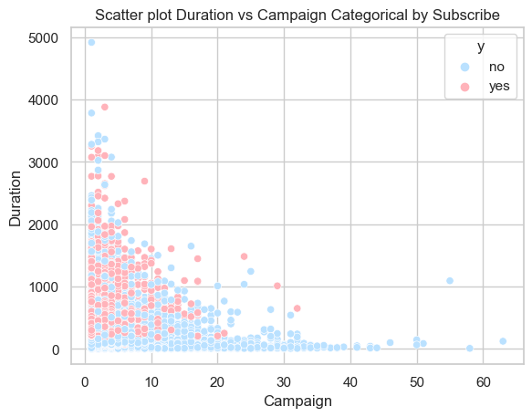

```python
sns.scatterplot(data=df,x='campaign',y='duration',hue='y')
plt.title('Scatter plot Duration vs Campaign Categorical by Subscribe')
plt.ylabel('Duration')
plt.xlabel('Campaign')
```

หลังจากแบ่งข้อมูลตามสถานะการเปิดบัญชีเงินฝากประจำพบว่า ยิ่งเคยถูกติดต่อน้อย และมีระยะเวลาการโทรที่นานจะทำให้มีโอกาสที่ลูกค้าคนนั้นจะเปิดบัญชีเงินฝากประจำมาก

**ตัวแปร Age และตัวแปร balance**

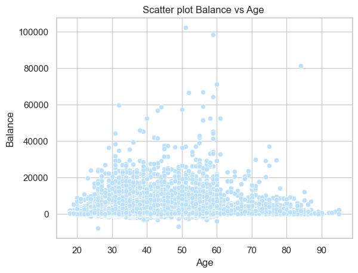

```python
sns.scatterplot(data=df,x='age',y='balance')
plt.title('Scatter plot Balance vs Age ')
plt.ylabel('Balance')
plt.xlabel('Age')
```

พบว่าตัวแปรอายุไม่ได้ส่งผลต่อตัวแปรยอดเงินในบัญชี